# Group6_Assignment4

Emma Flutsch, Roman Vazquez Lorenzo, Sarah Wu, Tanisha Yadav, Zhicong Hu

23/02/2022

# Assignment 4: Measuring Financial Risk and Big Data

## Introduction

In this assignment, we aim to understand the financial risk in the market. We began the assignment with the implementation of Value at Risk which is a risk measure used to access the riskiness of an asset based on loss. We implemented this measure for three different stocks. We then compared the number of violations for each VAR estimate based on actual return to access the validity of this measure.

Following, we implement big data techniques to deal with high dimensional data in the financial world. For stock portfolios, we compared the effectiveness of Fama-French 3 Factors and Principle Component Factors in explaining return variations within the portfolios. We also ran Principal Component analysis for treasury bond returns to find key factors explaining bond yields and support these factors with economic intuition.

## Q1: Implementing Value at Risk (VaR) in R

**Pick three stocks from the daily stock returns data set (PS1 Daily.xlsx) and transform these simple returns to log returns.**

```r
data <- read_excel(here("Data", "PS1_Daily.xlsx"), sheet = "HPR_daily")
colnames(data) <- data[1,]
data <- data[-1,]

# Convert date column to date variable
data$DATE <- ymd(data$DATE)

# Convert all other columns to numeric
data <- data %>% mutate_if(is.character, as.numeric)

# Pick MSFT, INTC, JPM
data <- data %>% select(DATE, MSFT, INTC, JPM)

# Transform to log returns
data[c("MSFT","INTC","JPM")] <- lapply(data[c("MSFT","INTC","JPM")], function(vector) log(1+vector)) %>% as.data.frame()
```

**Estimate three volatility time series for each of these three stocks by either using a MA (10 weeks) or an EWMA ($\lambda = 0.94$ and $\sigma_{0}^2=\frac{1}{T}\sum^{T}_{t=1}\sigma_{t}^2$, where T is number of observations of daily returns in your sample) model.**

```r
# Parameters for MA
window_length <- 50

# Initiate columns for MA
data$MSFT_MA <- NA
data$INTC_MA <- NA
data$JPM_MA <- NA

# For loop to calculate EWMA
for (i in (window_length+1):nrow(data)) {
  data[i, "MSFT_MA"] <- sum(data[(i-window_length):(i-1), "MSFT"]^2)/window_length
  data[i, "INTC_MA"] <- sum(data[(i-window_length):(i-1), "INTC"]^2)/window_length
  data[i, "JPM_MA"] <- sum(data[(i-window_length):(i-1), "JPM"]^2)/window_length
}

# Parameters for EWMA
lambda <- 0.94
initial_EWMA <- c(sum(data$MSFT^2)/length(data$MSFT),
                  sum(data$INTC^2)/length(data$INTC),
                  sum(data$JPM^2)/length(data$JPM))

# Initiate columns for EWMA
data$MSFT_EWMA <- c(initial_EWMA[1], rep(NA, nrow(data)-1))
data$INTC_EWMA <- c(initial_EWMA[2], rep(NA, nrow(data)-1))
data$JPM_EWMA <- c(initial_EWMA[3], rep(NA, nrow(data)-1))

# For loop to calculate EWMA
for (i in 2:nrow(data)) {
  data[i, "MSFT_EWMA"] <- (1-lambda)*(data[(i-1), "MSFT"])^2 + lambda*(data[(i-1), "MSFT_EWMA"])
  data[i, "INTC_EWMA"] <- (1-lambda)*(data[(i-1), "INTC"])^2 + lambda*(data[(i-1), "INTC_EWMA"])
  data[i, "JPM_EWMA"] <- (1-lambda)*(data[(i-1), "JPM"])^2 + lambda*(data[(i-1), "JPM_EWMA"])
}
```

**Based on these six time series (two volatility time series for each of the three stocks) calculate the daily one day Value-at-Risk (VaR) 95% assuming normality. That is, you should use the estimated volatility time series together with the following formula for conditional VaR assuming normality**

$$VaR_{95\%,t} = \bar{r} - \Phi^{-1}(0.05) \times \sigma_{t}$$

**where $\bar{r}$ is the mean return (i.e., the average return of the return series of interest up to time $t$), $\Phi^{-1}$ is the inverse of the standard normal cumulative density function and, hence, $\Phi^{-1}(0.05) = 1.65$ (the z score!). Moreover, $\sigma_{t}$ is your estimated volatility at time $t$.**

```r
# Parameters for VaR calculations
phi <- 1.65

# Initiate columns for MA VaR
data$MSFT_MA_VaR <- NA
data$INTC_MA_VaR <- NA
data$JPM_MA_VaR <- NA

# For loop to calculate MA VaR
for (i in (window_length+1):nrow(data)) {
  data[i, "MSFT_MA_VaR"] <- sum(data[1:(i-1), "MSFT"])/i - sqrt(phi*data[i, "MSFT_MA"])
  data[i, "INTC_MA_VaR"] <- sum(data[1:(i-1), "INTC"])/i - sqrt(phi*data[i, "INTC_MA"])
  data[i, "JPM_MA_VaR"] <- sum(data[1:(i-1), "JPM"])/i - sqrt(phi*data[i, "JPM_MA"])
}

# Initiate columns for EWMA VaR
data$MSFT_EWMA_VaR <- NA
data$INTC_EWMA_VaR <- NA
data$JPM_EWMA_VaR <- NA

# For loop to calculate EWMA VaR
for (i in 2:nrow(data)) {
  data[i, "MSFT_EWMA_VaR"] <- sum(data[1:(i-1), "MSFT"])/i - sqrt(phi*data[i, "MSFT_EWMA"])
  data[i, "INTC_EWMA_VaR"] <- sum(data[1:(i-1), "INTC"])/i - sqrt(phi*data[i, "INTC_EWMA"])
  data[i, "JPM_EWMA_VaR"] <- sum(data[1:(i-1), "JPM"])/i - sqrt(phi*data[i, "JPM_EWMA"])
}

# For the first day
data[1, "MSFT_EWMA_VaR"] <- data[1, "MSFT"] - sqrt(phi*data[1, "MSFT_EWMA"])
data[1, "INTC_EWMA_VaR"] <- data[1, "INTC"] - sqrt(phi*data[1, "INTC_EWMA"])
data[1, "JPM_EWMA_VaR"] <- data[1, "JPM"] - sqrt(phi*data[1, "JPM_EWMA"])
```

**In a last step, you are supposed to “backtest” your VaR estimates. That is, for each stock you now have three VaR series as well as the realized returns. With this data, count for each VaR estimate separately the number of violations. In other words, count the negative realized market returns that are more extreme than the VaR on this given day. For example, a violation of VaR occurs on a day when the realized returns is -9% and the VaR is -8%. How many violations would you expect if your VaR estimates were to be accurate (i.e., true)? How many violations do you observe? What do you conclude?**

```r
# Mutate violation column
data <- data %>%
  mutate(MSFT_MA_VaR_violations = ifelse(MSFT < MSFT_MA_VaR, 1, 0),
         INTC_MA_VaR_violations = ifelse(INTC < INTC_MA_VaR, 1, 0),
         JPM_MA_VaR_violations = ifelse(JPM < JPM_MA_VaR, 1, 0),
         MSFT_EWMA_VaR_violations = ifelse(MSFT < MSFT_EWMA_VaR, 1, 0),
         INTC_EWMA_VaR_violations = ifelse(INTC < INTC_EWMA_VaR, 1, 0),
         JPM_EWMA_VaR_violations = ifelse(JPM < JPM_EWMA_VaR, 1, 0),)
```

If our log return’s are normally distributed, we will assume that the number of violations is around 5% of the total trading days. This is because we used the Z-score of 1.65 in our VaR calculation, which is the Z-score of the 90% confidence interval. This means that the probability of performing below the VaR at any given day should be 5%.

```r
violations <- colSums(data %>% select(MSFT_MA_VaR_violations, INTC_MA_VaR_violations, JPM_MA_VaR_violations,
                                      MSFT_EWMA_VaR_violations, INTC_EWMA_VaR_violations, JPM_EWMA_VaR_violations), na.rm = TRUE)
violations
```

```
##   MSFT_MA_VaR_violations   INTC_MA_VaR_violations    JPM_MA_VaR_violations
##                      569                      544                      587
## MSFT_EWMA_VaR_violations INTC_EWMA_VaR_violations  JPM_EWMA_VaR_violations
##                      573                      557                      592
```

```r
data.frame(t(violations)) %>%
  pivot_longer(cols = everything(), names_to = "Type", values_to = "Number of Violations") %>%
  separate(Type, c("Stock", "Type")) %>%
  mutate(`Total Days` = ifelse(Type == "MA", nrow(data)-50, nrow(data))) %>%
  mutate(Percent = round((`Number of Violations`/`Total Days`)*100, 2)) %>%
  select(-`Number of Violations`, -`Total Days`) %>%
  pivot_wider(names_from = "Type", values_from = "Percent")
```

```
## # A tibble: 3 × 3
##   Stock    MA  EWMA
##   <chr> <dbl> <dbl>
## 1 MSFT   9.1   9.09
## 2 INTC   8.7   8.84
## 3 JPM    9.39  9.4
```

We can see that the percentage of violation is much higher than 5% for every stock, for both method of calculating volatility, 10 Week MA and EWMA. This suggest that the log returns of stocks are not normally distribution but instead has very heavy fat tails. Therefore, our assumption of normally distribution log returns and using Z-score for calculating VaR is invalid and results in higher than expected for number of violations.

## Q2: Portfolio Data Loading

**Go to Kenneth French’s webpage https://mba.tuck.dartmouth.edu/pages/faculty/ken.french/data library.html and download the 10 portfolios formed on operating profitability, investment, dividend yield, and momentum and the 49 industry portfolios at the monthly frequency. In addition, also download the Fama/French 3 factors at the monthly frequency.**

```r
OP_portfolios <- read_csv(here("Data", "Portfolios_Formed_on_OP.CSV"), skip = 24) %>%
  rename(Date = `...1`) %>% # change to X1 if there is an error (same for the following data)
  select(Date, `Lo 10`, `Dec 2`, `Dec 3`, `Dec 4`, `Dec 5`, `Dec 6`, `Dec 7`, `Dec 8`, `Dec 9`, `Hi 10`)
OP_portfolios <- OP_portfolios[1:(which(is.na(as.numeric(OP_portfolios$Date)))[1]-1),]

I_portfolios <- read_csv(here("Data", "Portfolios_Formed_on_INV.CSV"), skip = 17) %>%
  rename(Date = `...1`) %>%
  select(Date, `Lo 10`, `Dec 2`, `Dec 3`, `Dec 4`, `Dec 5`, `Dec 6`, `Dec 7`, `Dec 8`, `Dec 9`, `Hi 10`)
I_portfolios <- I_portfolios[1:(which(is.na(as.numeric(I_portfolios$Date)))[1]-1),]

DY_portfolios <- read_csv(here("Data", "Portfolios_Formed_on_D-P.CSV"), skip = 19) %>%
  rename(Date = `...1`) %>%
  select(Date, `Lo 10`, `Dec 2`, `Dec 3`, `Dec 4`, `Dec 5`, `Dec 6`, `Dec 7`, `Dec 8`, `Dec 9`, `Hi 10`)
DY_portfolios <- DY_portfolios[1:(which(is.na(as.numeric(DY_portfolios$Date)))[1]-1),]

M_portfolios <- read_csv(here("Data", "10_Portfolios_Prior_12_2.CSV"), skip = 10) %>%
  rename(Date = `...1`)
M_portfolios <- M_portfolios[1:(which(is.na(as.numeric(M_portfolios$Date)))[1]-1),]

I49_portfolios <- read_csv(here("Data", "49_Industry_Portfolios.CSV"), skip = 11) %>%
  rename(Date = `...1`)
I49_portfolios <- I49_portfolios[1:(which(is.na(as.numeric(I49_portfolios$Date)))[1]-1),]

factors <- read_csv(here("Data", "F-F_Research_Data_Factors.CSV"), skip = 3) %>%
  rename(Date = `...1`)
factors <- factors[1:(which(is.na(as.numeric(factors$Date)))[1]-1),]

# Set Data column
OP_portfolios$Date <- as.Date(paste0(OP_portfolios$Date, "01"), format = "%Y%m%d")
I_portfolios$Date <- as.Date(paste0(I_portfolios$Date, "01"), format = "%Y%m%d")
DY_portfolios$Date <- as.Date(paste0(DY_portfolios$Date, "01"), format = "%Y%m%d")
M_portfolios$Date <- as.Date(paste0(M_portfolios$Date, "01"), format = "%Y%m%d")
I49_portfolios$Date <- as.Date(paste0(I49_portfolios$Date, "01"), format = "%Y%m%d")
factors$Date <- as.Date(paste0(factors$Date, "01"), format = "%Y%m%d")

# Set numeric
OP_portfolios <- OP_portfolios %>% mutate_if(is.character, as.numeric)
I_portfolios <- I_portfolios %>% mutate_if(is.character, as.numeric)
DY_portfolios <- DY_portfolios %>% mutate_if(is.character, as.numeric)
M_portfolios <- M_portfolios %>% mutate_if(is.character, as.numeric)
I49_portfolios <- I49_portfolios %>% mutate_if(is.character, as.numeric)
factors <- factors %>% mutate_if(is.character, as.numeric)

# Clean I49_portfolios
I49_portfolios$Soda[I49_portfolios$Soda < -99] <- NA
I49_portfolios$Hlth[I49_portfolios$Hlth < -99] <- NA
I49_portfolios$Rubbr[I49_portfolios$Rubbr < -99] <- NA
I49_portfolios$FabPr[I49_portfolios$FabPr < -99] <- NA
I49_portfolios$Guns[I49_portfolios$Guns < -99] <- NA
I49_portfolios$Gold[I49_portfolios$Gold < -99] <- NA
I49_portfolios$PerSv[I49_portfolios$PerSv < -99] <- NA
I49_portfolios$Softw[I49_portfolios$Softw < -99] <- NA
I49_portfolios$Paper[I49_portfolios$Paper < -99] <- NA
```

## Q3: Principal Component Analysis

**Run a principal component on the combined excess returns of the 10 portfolios formed on operating profitability, investment, dividend yield, and momentum and the 49 industry portfolios (hint: use the prcomp command discussed in lecture 5). How many components/factors are needed to explain 95% of the return variation?**

```r
# joining data
all_portfolios <- OP_portfolios %>%
  inner_join(I_portfolios, by = "Date", suffix = c("_OP", "_I")) %>%
  inner_join(DY_portfolios, by = "Date", suffix = c("", "_DY")) %>%
  inner_join(M_portfolios, by = "Date", suffix = c("", "_M")) %>%
  inner_join(I49_portfolios, by = "Date", suffix = c("", "_I49")) %>%
  inner_join(factors %>% select(Date, risk_free = RF), by = "Date") %>%
  mutate(across(!risk_free & !Date, ~ . -risk_free)) %>%
  select(-risk_free) %>%
  drop_na()

# creating pca object with prcomp()
pca <- prcomp(all_portfolios %>% select(-Date), scale = T, center = T)

# summary of results
summary(pca)
```

```
## Importance of components:
##                           PC1    PC2     PC3     PC4     PC5     PC6     PC7
## Standard deviation     7.8730 1.6611 1.45924 1.32926 1.23293 1.02506 0.98553
## Proportion of Variance 0.6965 0.0310 0.02393 0.01985 0.01708 0.01181 0.01091
## Cumulative Proportion  0.6965 0.7275 0.75138 0.77123 0.78831 0.80012 0.81103
##                            PC8     PC9   PC10    PC11    PC12    PC13    PC14
## Standard deviation     0.93625 0.87650 0.8384 0.81601 0.75905 0.73954 0.70794
## Proportion of Variance 0.00985 0.00863 0.0079 0.00748 0.00647 0.00615 0.00563
## Cumulative Proportion  0.82088 0.82951 0.8374 0.84489 0.85136 0.85751 0.86314
##                           PC15    PC16    PC17    PC18    PC19    PC20    PC21
## Standard deviation     0.69104 0.68318 0.66648 0.65997 0.63846 0.62503 0.61804
## Proportion of Variance 0.00537 0.00524 0.00499 0.00489 0.00458 0.00439 0.00429
## Cumulative Proportion  0.86851 0.87375 0.87874 0.88364 0.88822 0.89261 0.89690
##                           PC22    PC23    PC24    PC25    PC26    PC27    PC28
## Standard deviation     0.60105 0.59255 0.58586 0.57936 0.56880 0.55276 0.54127
## Proportion of Variance 0.00406 0.00395 0.00386 0.00377 0.00364 0.00343 0.00329
## Cumulative Proportion  0.90096 0.90490 0.90876 0.91253 0.91616 0.91960 0.92289
##                           PC29    PC30    PC31    PC32    PC33    PC34    PC35
## Standard deviation     0.53791 0.53234 0.50354 0.49117 0.48481 0.47835 0.47103
## Proportion of Variance 0.00325 0.00318 0.00285 0.00271 0.00264 0.00257 0.00249
## Cumulative Proportion  0.92614 0.92932 0.93217 0.93488 0.93753 0.94010 0.94259
##                           PC36    PC37    PC38    PC39   PC40    PC41    PC42
## Standard deviation     0.46681 0.46434 0.45813 0.43878 0.4319 0.41668 0.41002
## Proportion of Variance 0.00245 0.00242 0.00236 0.00216 0.0021 0.00195 0.00189
## Cumulative Proportion  0.94504 0.94746 0.94982 0.95198 0.9541 0.95603 0.95792
##                           PC43    PC44    PC45    PC46   PC47    PC48    PC49
## Standard deviation     0.40308 0.39802 0.39423 0.38434 0.3773 0.37108 0.36228
## Proportion of Variance 0.00183 0.00178 0.00175 0.00166 0.0016 0.00155 0.00147
## Cumulative Proportion  0.95974 0.96152 0.96327 0.96493 0.9665 0.96808 0.96955
##                           PC50    PC51   PC52    PC53    PC54    PC55    PC56
## Standard deviation     0.34456 0.34342 0.3395 0.33222 0.32847 0.32277 0.32221
## Proportion of Variance 0.00133 0.00133 0.0013 0.00124 0.00121 0.00117 0.00117
## Cumulative Proportion  0.97088 0.97221 0.9735 0.97474 0.97596 0.97713 0.97829
##                           PC57    PC58    PC59    PC60    PC61    PC62    PC63
## Standard deviation     0.31675 0.30551 0.29758 0.29670 0.28771 0.28589 0.28524
## Proportion of Variance 0.00113 0.00105 0.00099 0.00099 0.00093 0.00092 0.00091
## Cumulative Proportion  0.97942 0.98047 0.98146 0.98245 0.98338 0.98430 0.98522
##                           PC64    PC65    PC66    PC67    PC68    PC69    PC70
## Standard deviation     0.27554 0.27171 0.26938 0.26512 0.26426 0.25215 0.24629
## Proportion of Variance 0.00085 0.00083 0.00082 0.00079 0.00078 0.00071 0.00068
## Cumulative Proportion  0.98607 0.98690 0.98771 0.98850 0.98929 0.99000 0.99068
##                           PC71    PC72    PC73    PC74    PC75    PC76    PC77
## Standard deviation     0.24281 0.24027 0.23570 0.23415 0.22980 0.22803 0.22443
## Proportion of Variance 0.00066 0.00065 0.00062 0.00062 0.00059 0.00058 0.00057
## Cumulative Proportion  0.99135 0.99200 0.99262 0.99324 0.99383 0.99441 0.99498
##                           PC78    PC79    PC80    PC81    PC82    PC83    PC84
## Standard deviation     0.22070 0.21721 0.21347 0.20784 0.20562 0.20167 0.19935
## Proportion of Variance 0.00055 0.00053 0.00051 0.00049 0.00048 0.00046 0.00045
## Cumulative Proportion  0.99553 0.99606 0.99657 0.99705 0.99753 0.99799 0.99843
##                           PC85   PC86    PC87    PC88    PC89
## Standard deviation     0.19580 0.1884 0.17734 0.16614 0.08127
## Proportion of Variance 0.00043 0.0004 0.00035 0.00031 0.00007
## Cumulative Proportion  0.99886 0.9993 0.99962 0.99993 1.00000
```

From the cumulative proportion of our principal components in the summary results above, we can see that we need 39 components to explain 95% of the return variations. It is important to notice that the PC1 is able to explain close to 70% of the return variations, and the first 6 PCs is able to explain more than 80% of the return variations. Since we are using vastly different portfolios that should have vastly different stocks in them, our PCs will be a good estimate for factors that are applicable for the entire market.

## Q4: Regression on Factors

**Run the following regressions for the 10 portfolios formed on operating profitability, investment, dividend yield, and momentum and the 49 industry portfolios and save all regression adjusted** $R^2$:

$$r_{i,t} − r_{f,t} = \alpha_i + \beta_i(r_{MKT,t} − r_{f,t}) + \gamma_ir_{SMB,t} + \delta_ir_{HML,t} + \epsilon_{i,t}$$

**What is the average and median regression adjusted $R^2$? What is the standard deviation of adjusted $R^2$?**

```r
# create empty list for results
factors_r2 <- data.frame(portfolios = c(rep("OP", 10), rep("Inv", 10), rep("DY", 10), rep("Mom", 10), rep("Industry", 49)),
                         rsquared = NA)
# regression
for (i in 2:(length(all_portfolios))){
  temp_df <- all_portfolios[,c(1,i)] %>% inner_join(factors %>% select(-RF), by = "Date") %>% select(-Date)
  temp_model <- lm(temp_df)
  factors_r2[i-1, "rsquared"] <- summary(temp_model)$adj.r.squared
}
# printing results
cat("The average adjusted R-squared is", mean(factors_r2$rsquared),
    "\nThe median adjusted R-squared is", median(factors_r2$rsquared),
    "\nThe standard deviation of adjusted R-squared is", sd(factors_r2$rsquared))
```

```
## The average adjusted R-squared is 0.7099859
## The median adjusted R-squared is 0.75081
## The standard deviation of adjusted R-squared is 0.1852799
```

The average adjusted R-squared for all portfolios is 0.710 and median adjusted R-squared for all portfolios is 0.751. The standard deviation of R-squared for all portfolios is 0.185. However, we will want to examine where these factors works equally well for all portfolios, or whether if there are specific portfolios that these factors fail.

```r
factors_r2 %>% group_by(portfolios) %>% summarise(Mean_Rsquared = mean(rsquared))
```

```
## # A tibble: 5 × 2
##   portfolios Mean_Rsquared
##   <chr>              <dbl>
## 1 DY                 0.828
## 2 Industry           0.589
## 3 Inv                0.898
## 4 Mom                0.807
## 5 OP                 0.901
```

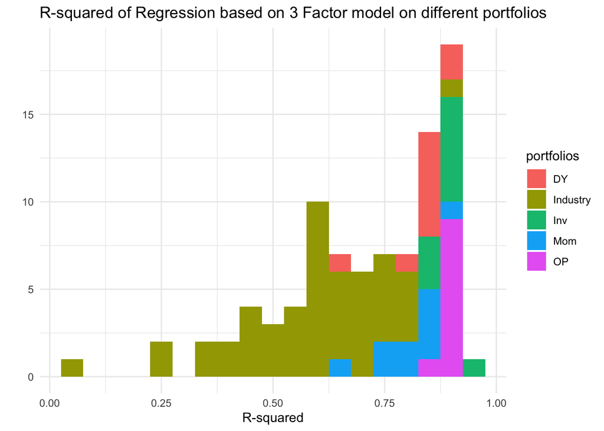

```r
ggplot(factors_r2, aes(x = rsquared, fill = portfolios)) +
  geom_histogram(binwidth = 0.05) +
  theme_minimal() +
  labs(x = "R-squared",
       y = "",
       title = "R-squared of Regression based on 3 Factor model on different portfolios")
```

As we can see from the table and distribution of R-squared, the Fama-French three factor model is unable to explain the return variations of Industry-specific portfolios very well, with only a mean R-squared of 0.59. It does not work very well for Momentum-specific portfolios as well with a mean R-squared of 0.81.

## Q5: Regression on Principal Components

**Now, run the following regressions for the 10 portfolios formed on operating profitability, investment, dividend yield, and momentum and the 49 industry portfolios and save all regression adjusted $R^2$:**

$$r_{i,t} − r_{f,t} = \alpha_i + \beta_ir_{PC1,t} + \gamma_ir_{PC2,t} + \delta_ir_{PC3,t} + \epsilon_{i,t}$$

**(hint: $r_{PC1,t}$, $r_{PC2,t}$, $r_{PC3,t}$ are simply the first three principal components. These components are returns themselves as the principal components of excess returns are simply linear combinations (i.e., portfolios) thereof, i.e., excess returns. Also note that you can call these first three principal components as follows in R: pca$x[,1], pca$x[,2], and pca$x[,3].)**

**What is the average and median regression adjusted $R^2$? What is the standard deviation of adjusted $R^2$? Compare and discuss your results with the ones from above!**

```r
# putting first 3 principle components into data frame
pc_df <- data.frame(Date = all_portfolios$Date, PC1 = pca$x[,1], PC2 = pca$x[,2], PC3 = pca$x[,3])

# creating empty list for results
pc_r2 <- data.frame(portfolios = c(rep("OP", 10), rep("Inv", 10), rep("DY", 10), rep("Mom", 10), rep("Industry", 49)),
                    rsquared = NA)
# regression
for (i in 2:(length(all_portfolios))){
  temp_df <- all_portfolios[,c(1,i)] %>% inner_join(pc_df, by = "Date") %>% select(-Date)
  temp_model <- lm(temp_df)
  pc_r2[i-1, "rsquared"] <- summary(temp_model)$adj.r.squared
}
# printing results
cat("The average adjusted R-squared is", mean(pc_r2$rsquared),
    "\nThe median adjusted R-squared is", median(pc_r2$rsquared),
    "\nThe standard deviation of adjusted R-squared is", sd(pc_r2$rsquared))
```

```
## The average adjusted R-squared is 0.7501864
## The median adjusted R-squared is 0.786202
## The standard deviation of adjusted R-squared is 0.1544888
```

Using first three principle components as factors, the average adjusted R-squared for all portfolios is 0.750 and median adjusted R-squared for all portfolios is 0.786, which are both higher than using Fama-French factors. The standard deviation of R-squared for all portfolios is lower than using Fama-French factors. This means that principle components are better predictors for excess return since they account for more variation in excess return. However, we will want to investigate deeper if the effectiveness of these PC factors is consistent for all types of portfolios.

```r
pc_r2 %>% group_by(portfolios) %>% summarise(Mean_Rsquared = mean(rsquared))
```

```
## # A tibble: 5 × 2
##   portfolios Mean_Rsquared
##   <chr>              <dbl>
## 1 DY                 0.859
## 2 Industry           0.651
## 3 Inv                0.894
## 4 Mom                0.842
## 5 OP                 0.890
```

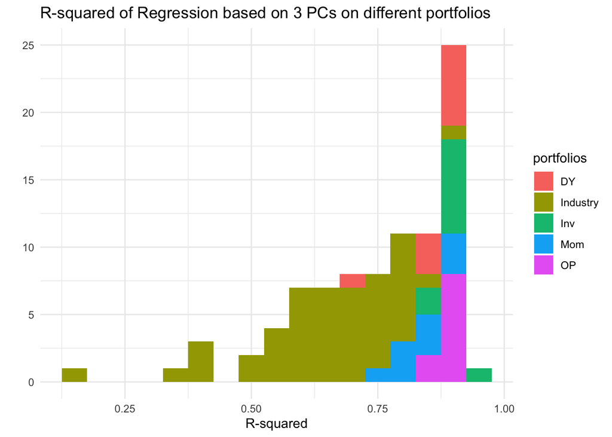

```r
ggplot(pc_r2, aes(x = rsquared, fill = portfolios)) +
  geom_histogram(binwidth = 0.05) +
  theme_minimal() +
  labs(x = "R-squared",
       y = "",
       title = "R-squared of Regression based on 3 PCs on different portfolios")
```

Comparing the regression results of Fama-French 3 factors and 3 PC factors, we can see that our 3 PC factors is able to explain return variations of Industry-specific portfolios much better, with an increase in R-squared of over 10%. Our 3 PC factors also works much better for Momentum-specific portfolios. Therefore, we can suggest that our PC factors involves some components regarding industry and momentum. However, the mean R-squared of Operating Profitability and Investment specific portfolios decreased slightly but the drop is negligible.

## Q6: Limitations of Principal Component Factors

**What are the problems with factor models based on principal components?**

1. Principle Component factors are not interpretable as they are merely a linear combinations of returns of each date in our dataset. On the other hand, Fama-French 3 factors are very interpretable as they are the returns of long-short portfolios built based on stock characteristics.
2. Principle Component factor are not supported by economic intuition while Fama-French 3 factors is much more explainable due to its nature of being interpretable. Therefore, PC factors are unable to answer questions like what economic forces cause prices to move.
3. Since our Principle Components are built within our dataset, it is fitted to our current dataset which might not be representive of the future. Therefore, further out-of-sample testing might be required.

## Q7: Treasury Yield Data

**Go to CANVAS and download the data file PS4 Daily.xlsx. This file contains daily yield curve data for the United States between July 2 1981 and January 31 2020. In particular, you are given spot rates for 1-year, 2-years, …, 20-years.**

```r
#Load data and clean
PS4_daily <- read_xlsx(here("Data", "PS4_Daily.xlsx"), col_types =c("date" , replicate(20, "numeric"))) %>%
  filter(!SVENY01 == 'NA') %>%
  drop_na() %>%
  clean_names()
  # mutate(date = as_date(date))
  # select(starts_with('sveny')) %>%
  # mutate_all(c()

skimr::skim(PS4_daily) # check for NAs and see dates
```

Data summary

| Name | PS4_daily |
| --- | --- |
| Number of rows | 9626 |
| Number of columns | 21 |
| _______________________ |  |
| Column type frequency: |  |
| numeric | 20 |
| POSIXct | 1 |
| ________________________ |  |
| Group variables | None |

**Variable type: numeric**

| skim_variable | n_missing | complete_rate | mean | sd | p0 | p25 | p50 | p75 | p100 | hist |
| --- | --- | --- | --- | --- | --- | --- | --- | --- | --- | --- |
| sveny01 | 0 | 1 | 4.40 | 3.42 | 0.08 | 1.25 | 4.40 | 6.37 | 16.46 | ▇▇▃▁▁ |
| sveny02 | 0 | 1 | 4.67 | 3.44 | 0.16 | 1.58 | 4.59 | 6.74 | 15.91 | ▇▆▃▁▁ |
| sveny03 | 0 | 1 | 4.90 | 3.40 | 0.30 | 1.76 | 4.64 | 6.99 | 15.57 | ▇▆▅▂▁ |
| sveny04 | 0 | 1 | 5.10 | 3.33 | 0.43 | 2.08 | 4.80 | 7.20 | 15.35 | ▇▆▅▂▁ |
| sveny05 | 0 | 1 | 5.28 | 3.27 | 0.59 | 2.43 | 4.94 | 7.35 | 15.18 | ▇▇▅▂▁ |
| sveny06 | 0 | 1 | 5.44 | 3.21 | 0.76 | 2.71 | 5.04 | 7.50 | 15.06 | ▇▇▅▂▁ |
| sveny07 | 0 | 1 | 5.58 | 3.15 | 0.94 | 2.88 | 5.16 | 7.61 | 15.01 | ▇▇▅▂▁ |
| sveny08 | 0 | 1 | 5.70 | 3.10 | 1.12 | 3.09 | 5.29 | 7.70 | 14.98 | ▇▇▅▂▁ |
| sveny09 | 0 | 1 | 5.80 | 3.06 | 1.30 | 3.32 | 5.40 | 7.75 | 14.96 | ▇▇▅▂▁ |
| sveny10 | 0 | 1 | 5.90 | 3.02 | 1.40 | 3.53 | 5.49 | 7.81 | 14.94 | ▇▇▅▂▁ |
| sveny11 | 0 | 1 | 5.98 | 2.99 | 1.46 | 3.70 | 5.57 | 7.87 | 14.93 | ▆▇▅▂▁ |
| sveny12 | 0 | 1 | 6.05 | 2.97 | 1.51 | 3.86 | 5.63 | 7.91 | 14.94 | ▆▇▅▂▁ |
| sveny13 | 0 | 1 | 6.11 | 2.94 | 1.55 | 3.99 | 5.69 | 7.96 | 14.94 | ▆▇▅▂▁ |
| sveny14 | 0 | 1 | 6.16 | 2.93 | 1.59 | 4.08 | 5.73 | 8.00 | 14.97 | ▆▇▅▂▁ |
| sveny15 | 0 | 1 | 6.21 | 2.91 | 1.64 | 4.15 | 5.78 | 8.02 | 15.04 | ▆▇▅▂▁ |
| sveny16 | 0 | 1 | 6.25 | 2.90 | 1.68 | 4.20 | 5.80 | 8.05 | 15.11 | ▅▇▅▂▁ |
| sveny17 | 0 | 1 | 6.28 | 2.89 | 1.72 | 4.26 | 5.83 | 8.06 | 15.17 | ▅▇▅▂▁ |
| sveny18 | 0 | 1 | 6.31 | 2.88 | 1.76 | 4.30 | 5.85 | 8.08 | 15.23 | ▆▇▅▂▁ |
| sveny19 | 0 | 1 | 6.33 | 2.88 | 1.80 | 4.34 | 5.86 | 8.09 | 15.29 | ▆▇▅▂▁ |
| sveny20 | 0 | 1 | 6.35 | 2.88 | 1.83 | 4.37 | 5.87 | 8.10 | 15.34 | ▆▇▅▂▁ |

**Variable type: POSIXct**

| skim_variable | n_missing | complete_rate | min | max | median | n_unique |
| --- | --- | --- | --- | --- | --- | --- |
| date | 0 | 1 | 1981-07-02 | 2020-01-31 | 2000-10-31 12:00:00 | 9626 |